[O’Hara on GitHub](https://github.com/oharac)

# Collect length/body size trait

Compiled on Mon Mar 28 13:20:31 2022 by ohara

```r
knitr::opts_chunk$set(echo = TRUE, message = FALSE, warning = FALSE)

library(oharac)
library(tidyverse)
library(here)
library(rfishbase)
source(here('common_fxns.R'))
source('fb_slb_fxns.R')
```

# 1 Summary

Gather data on body length from FishBase and the species vulnerability project. Gapfill using downfill and upstream-downstream gapfill methodology.

# 2 Data

This script will use processed valid species traits from the species vulnerability project, plus FishBase and SeaLifeBase.

FishBase is a scientific database, and this has the implication - among others - that its use and the use of its contents are free as long as due credit is given.

This may be done at different levels, for which we suggest different forms of citations:

- when referring to FishBase concepts and design, cite its architects (Froese and Pauly 2000);
- when referring to a set of values extracted from a FishBase table, cite the author(s) of the original data, e.g., “Houde and Zastrow (1993)”, or “Welcomme (1988)”. To help us track the use of FishBase in the literature, we would appreciate your also citing Froese and Pauly (2000) in an appropriate part of your text, as the source of the information;
- when discussing the features of a FishBase table, cite the section documenting that table, e.g., “Sa-a et al. (2000).”

## 2.1 References

- Froese, R. and D. Pauly, Editors. 2000. FishBase 2000: concepts, design and data sources. ICLARM, Los Baños, Laguna, Philippines. 344 p.
- Houde, E.D. and C.E. Zastrow. 1993. Ecosystem- and taxon-specific dynamic energetics properties of fish larvae assemblages. Bull. Mar. Sci. 53(2):290-335.
- Sa-a, P., M.L. Palomares and D. Pauly. 2000. The FOOD ITEMS table, p. 182-188. In R. Froese and D. Pauly (eds.) FishBase 2000: concepts, design and data sources. ICLARM, Los Baños, Laguna, Philippines. 344 p.
- Welcomme, R.L. 1988. International introductions of inland aquatic species. FAO Fish. Tech. Pap. 294, 318 p.

# 3 Methods

## 3.1 Read in data

Read in data from fishbase/sealifebase, from Species table.

```r
l_spp_fb_f <- here('int/fb_length_spp_raw.csv')
if(!file.exists(l_spp_fb_f)) {

  keep_cols <- c('f_bname', 'length')
  length_spp_fb_raw <- get_fb_slb(fxn = species,
                              keep_cols = keep_cols, keep_fxn = contains,
                              drop_cols = '_ref',    drop_fxn = ends_with)

  length_spp_fb <- length_spp_fb_raw %>%
    mutate(across(contains('length'), ~ as.numeric(.x)),
           spec_code = as.integer(spec_code)) %>%
    select(spec_code, species, db,
           length, length_female,
           common_length, common_length_f) %>%
    ### drop rows with no useful values at all...
    filter(!is.na(length) | !is.na(length_female) | !is.na(common_length) | !is.na(common_length_f)) %>%
    ### what is up with these NA spec codes?
    filter(!is.na(spec_code)) %>%
    distinct() %>%
    mutate(table = 'species')

  write_csv(length_spp_fb, l_spp_fb_f)
}

length_spp_fb <- read_csv(l_spp_fb_f)
```

### 3.1.1 Gapfill max length using common length or female length

Because the FishBase/SeaLifeBase species contains multiple columns with length information, use that to help gapfill species where `length` data is NA but `common_length` or `length_female` is not NA. First remove the outlier of common length = 916000 (*Dermochelys coriacea* are not nine kilometers long)

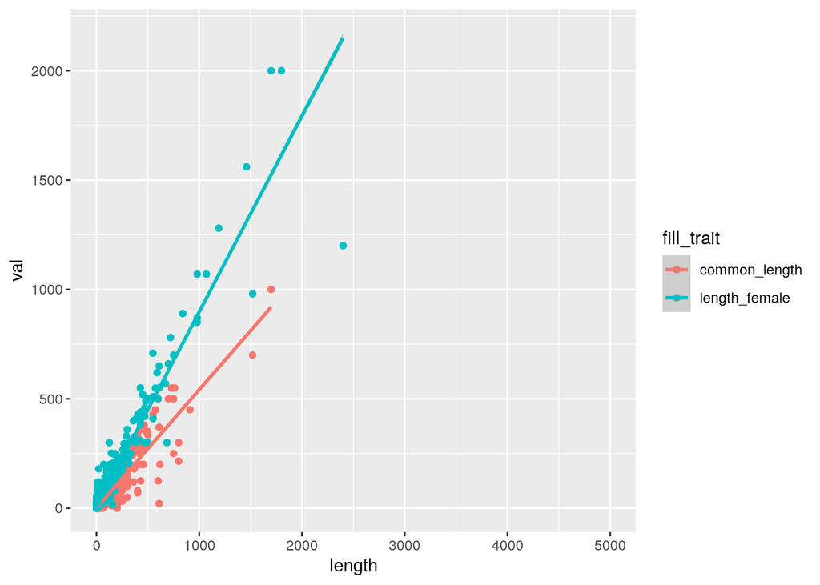

```r
length_df_outlier_removed <- length_spp_fb %>%
    filter(common_length < 2500 | is.na(common_length))

ggplot(length_df_outlier_removed %>%
         gather(fill_trait, val, common_length, length_female),
       aes(x = length, y = val, color = fill_trait)) +
  geom_point() +
  geom_smooth(method = 'lm')
```

```r
x <- lm(common_length ~ length, data = length_df_outlier_removed)
summary(x)
```

```
##
## Call:
## lm(formula = common_length ~ length, data = length_df_outlier_removed)
##
## Residuals:
##      Min       1Q   Median       3Q      Max
## -310.162   -2.647   -0.319    3.201  154.055
##
## Coefficients:
##             Estimate Std. Error t value Pr(>|t|)
## (Intercept) 1.849625   0.287004   6.445 1.28e-10 ***
## length      0.539856   0.003176 169.992  < 2e-16 ***
## ---
## Signif. codes:  0 '***' 0.001 '**' 0.01 '*' 0.05 '.' 0.1 ' ' 1
##
## Residual standard error: 16.26 on 4587 degrees of freedom
##   (40320 observations deleted due to missingness)
## Multiple R-squared:  0.863,  Adjusted R-squared:  0.863
## F-statistic: 2.89e+04 on 1 and 4587 DF,  p-value: < 2.2e-16
```

```r
y <- lm(length_female ~ length, data = length_spp_fb)
summary(y)
```

```
##
## Call:
## lm(formula = length_female ~ length, data = length_spp_fb)
##
## Residuals:
##     Min      1Q  Median      3Q     Max
## -950.78   -3.18   -2.40   -0.06  475.65
##
## Coefficients:
##             Estimate Std. Error t value Pr(>|t|)
## (Intercept) 3.018775   0.583065   5.177 2.41e-07 ***
## length      0.894899   0.004999 179.003  < 2e-16 ***
## ---
## Signif. codes:  0 '***' 0.001 '**' 0.01 '*' 0.05 '.' 0.1 ' ' 1
##
## Residual standard error: 29.19 on 2735 degrees of freedom
##   (42173 observations deleted due to missingness)
## Multiple R-squared:  0.9214, Adjusted R-squared:  0.9213
## F-statistic: 3.204e+04 on 1 and 2735 DF,  p-value: < 2.2e-16
```

```r
l_c_coeff <- x$coefficients[2]
l_f_coeff <- y$coefficients[2]
```

`length_female ~ length` shows an intercept of 3 cm, a coefficient of .89, with highly significant p values and R<sup>2</sup> around 92%. This has strong potential to gapfill max length ~700 spp.

Only 11 spp have no `length` but both `common_length` and `length_female`.

```r
length_lm_fb <- length_spp_fb %>%
  mutate(l_value = case_when(!is.na(length) ~ length,
                             !is.na(length_female) ~ round(length_female / l_f_coeff, 2),
                             !is.na(common_length) ~ round(common_length / l_c_coeff, 2),
                             TRUE ~ NA_real_)) %>%
  mutate(l_column = case_when(!is.na(length) ~ 'length',
                              !is.na(length_female) ~ 'length_female',
                              !is.na(common_length) ~ 'common_length',
                              TRUE ~ NA_character_)) %>%
  select(db, spec_code, species, length = l_value, l_column) %>%
  distinct()
```

## 3.2 Check other tables

These tables were mentioned in SI for Boyce et al. Climate Vulnerability Index

### 3.2.1 Morphology

```r
l_morpho_fb_f <- here('int/fb_length_morpho_raw.csv')
if(!file.exists(l_morpho_fb_f)) {

  keep_cols <- c('f_bname', 'length')
  length_morpho_fb_raw <- get_fb_slb(fxn = morphology,
                              keep_cols = keep_cols, keep_fxn = contains,
                              drop_cols = '_ref',    drop_fxn = ends_with)

  length_morpho_fb <- length_morpho_fb_raw %>%
    select(spec_code, species, db,
           total_length = totallength,
           fork_length  = forklength,
           std_length   = standard_length_cm) %>%
    mutate(across(contains('length'), ~ as.numeric(.x)),
           spec_code    = as.integer(spec_code),
           in_spp_table = species %in% length_spp_fb$species) %>%
    filter(!is.na(total_length) | !is.na(fork_length) | !is.na(std_length)) %>%
    filter(!is.na(spec_code)) %>%
    distinct() %>%
    mutate(table = 'morphology')

  write_csv(length_morpho_fb, l_morpho_fb_f)
}

length_morpho_fb <- read_csv(l_morpho_fb_f)
```

The small number of species with `total_length`, `fork_length`, or `standard_length_cm` values in the Morpohology table are already included in the Species table.

### 3.2.2 PopLL

```r
l_popll_fb_f <- here('int/fb_length_popll_raw.csv')
if(!file.exists(l_popll_fb_f)) {

  length_popll_fb_raw <- get_fb_slb(fxn = popll,
                              keep_cols = NULL, keep_fxn = contains,
                              drop_cols = '_ref',    drop_fxn = ends_with)

  length_popll_fb <- length_popll_fb_raw %>%
    select(spec_code, species, db, length_max) %>%
    mutate(length_max = as.numeric(length_max),
           spec_code  = as.integer(spec_code),
           in_spp_table = species %in% length_spp_fb$species) %>%
    filter(!is.na(length_max)) %>%
    filter(!is.na(spec_code)) %>%
    distinct() %>%
    mutate(table = 'popll')

  write_csv(length_popll_fb, l_popll_fb_f)
}

length_popll_fb <- read_csv(l_popll_fb_f)
```

A few species here (~55) not included in the Species table…

### 3.2.3 PopLW

```r
l_poplw_fb_f <- here('int/fb_length_poplw_raw.csv')
if(!file.exists(l_poplw_fb_f)) {

  length_poplw_fb_raw <- get_fb_slb(fxn = poplw,
                              keep_cols = NULL, keep_fxn = contains,
                              drop_cols = '_ref',    drop_fxn = ends_with)

  length_poplw_fb <- length_poplw_fb_raw %>%
    select(spec_code, species, db, length_max) %>%
    mutate(length_max = as.numeric(length_max),
           spec_code  = as.integer(spec_code),
           in_spp_table = species %in% length_spp_fb$species) %>%
    filter(!is.na(length_max)) %>%
    filter(!is.na(spec_code)) %>%
    distinct() %>%
    mutate(table = 'poplw')

  write_csv(length_poplw_fb, l_poplw_fb_f)
}

length_poplw_fb <- read_csv(l_poplw_fb_f)
```

A few more species here (~293) not included in the Species table…

### 3.2.4 PopChar

```r
l_popchar_fb_f <- here('int/fb_length_popchar_fb_raw.csv')
if(!file.exists(l_popchar_fb_f)) {

  length_popchar_fb_raw <- get_fb_slb(fxn = popchar,
                              keep_cols = NULL, keep_fxn = contains,
                              drop_cols = '_ref',    drop_fxn = ends_with)

  length_popchar_fb <- length_popchar_fb_raw %>%
    select(spec_code, species, db, length_max = lmax) %>%
    mutate(length_max = as.numeric(length_max),
           spec_code  = as.integer(spec_code),
           in_spp_table = species %in% length_spp_fb$species) %>%
    filter(!is.na(length_max)) %>%
    filter(!is.na(spec_code)) %>%
    distinct() %>%
    mutate(table = 'popchar')

  write_csv(length_popchar_fb, l_popchar_fb_f)
}

length_popchar_fb <- read_csv(l_popchar_fb_f)
```

Quite a few more species here (~895) not included in the Species table…

### 3.2.5 Maturity

```r
l_mat_fb_f <- here('int/fb_length_maturity_raw.csv')
if(!file.exists(l_mat_fb_f)) {

  length_mat_fb_raw <- get_fb_slb(fxn = maturity,
                              keep_cols = NULL, keep_fxn = contains,
                              drop_cols = '_ref',    drop_fxn = ends_with)

  length_mat_fb <- length_mat_fb_raw %>%
    select(spec_code, species, db, length_max = lm) %>%
    mutate(length_max = as.numeric(length_max),
           spec_code  = as.integer(spec_code),
           in_spp_table = species %in% length_spp_fb$species) %>%
    filter(!is.na(length_max)) %>%
    filter(!is.na(spec_code)) %>%
    filter(length_max <= 1500) %>% ### drop absurdly long Balaenoptera borealis
    distinct() %>%
    mutate(table = 'maturity')

  write_csv(length_mat_fb, l_mat_fb_f)
}

length_mat_fb <- read_csv(l_mat_fb_f)
```

A few more species here (~40) not included in the Species table…

## 3.3 Gather the tables together

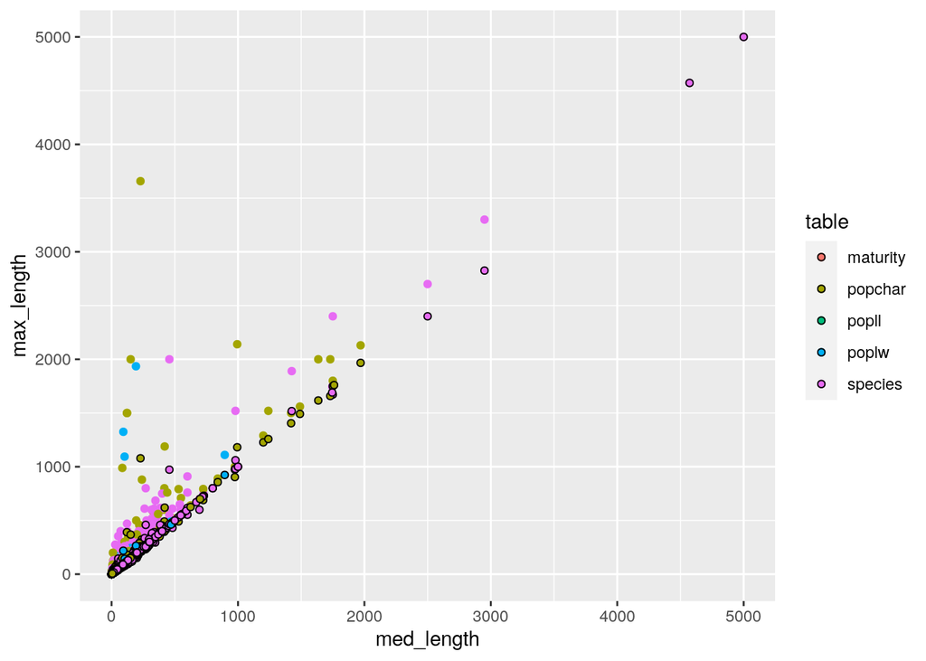

```r
length_fb_all <- length_lm_fb %>%
  mutate(table = 'species') %>%
  bind_rows(length_popchar_fb %>% rename(length = length_max)) %>%
  bind_rows(length_popll_fb %>% rename(length = length_max)) %>%
  bind_rows(length_poplw_fb %>% rename(length = length_max)) %>%
  bind_rows(length_mat_fb %>% rename(length = length_max)) %>%
  filter(!is.na(length)) %>%
  group_by(db, spec_code, species) %>%
  arrange(desc(length)) %>%
  summarize(table = first(table),
            max_length  = max(length),
            mean_length = mean(length),
            med_length  = median(length),
            n_length    = n_distinct(length)) %>%
  mutate(mean_med_ratio = mean_length/med_length)

ggplot(length_fb_all, aes(x = med_length, y = max_length)) +
  geom_point(aes(color = table)) +
  geom_point(aes(y = mean_length, fill = table), shape = 21)
```

It seems that some records are rather absurdly large, probably owing to mismatches in units (e.g., *Hucho taimen* salmon at 2000 cm? probably more like 200 cm) or measuring different aspects (e.g., *Cyanea capillata* lion’s mane jelly, max = 3657 cm is probably length of tentacles while median = 229 cm is probably diameter of disk). For this reason, conservatively let’s use the mean or median value where multiple values are available.

```r
length_fb <- length_fb_all %>%
  select(db, spec_code, species, length = med_length) %>%
  distinct()
```

## 3.4 Use WoRMS API to resolve names

```r
record_df <- collect_records(length_fb, field = 'length',
                             file_tag = 'resolve_names_fb_length') %>%
  filter(aphia_id != -9999)

length_fb_fixed <- length_fb %>%
  left_join(record_df, by = c('species' = 'orig_sciname')) %>%
  mutate(species = ifelse(!is.na(valid_name), valid_name, species)) %>%
  mutate(species = str_extract(species, '^[a-z]+ [a-z]+')) %>%
    ### this drops subspp and var. names
  select(-aphia_id, -valid_name) %>%
  distinct()

write_csv(length_fb_fixed, here('_data/fb_traits/trait_length_cm.csv'))
```